# FinalProject

Group 3

## Section 1 - Loading the data and Exploring the data

We have selected Bike dataset to perform exploration of the data. We start by loading the data into the R Markdown file

```r
bike_data <- read_csv("Cleaned_bike_data.csv",show_col_types = FALSE)
```

```r
summary(bike_data)
```

```
##   model_name          model_year     kms_driven         owner
##  Length:5062        Min.   :1970   Min.   :      0   Length:5062
##  Class :character   1st Qu.:2014   1st Qu.:   9782   Class :character
##  Mode  :character   Median :2016   Median :  18000   Mode  :character
##                     Mean   :2015   Mean   :  24079
##                     3rd Qu.:2018   3rd Qu.:  30708
##                     Max.   :2021   Max.   :1000000
##    location            mileage         power            price
##  Length:5062        Min.   : 5.0   Min.   :  6.15   Min.   :      0
##  Class :character   1st Qu.:35.0   1st Qu.: 14.00   1st Qu.:  44925
##  Mode  :character   Median :38.0   Median : 19.80   Median :  80000
##                     Mean   :41.8   Mean   : 21.93   Mean   : 115390
##                     3rd Qu.:53.0   3rd Qu.: 24.60   3rd Qu.: 133375
##                     Max.   :95.0   Max.   :197.30   Max.   :1900000
```

We can see that there are different columns in the table which are Model_name, Model_year, Kms_driven, Owner, Location, Mileage, Power and Price.

To determine the different types of the datatypes, we can use the str command in R. This command tells us the different types of data which is present in the datasheet.

```r
str(bike_data)
```

```
## spec_tbl_df [5,062 × 8] (S3: spec_tbl_df/tbl_df/tbl/data.frame)
##  $ model_name: chr [1:5062] "Bajaj Avenger Cruise" "Royal Enfield Classic" "Hyosung GT250R 2012" "KTM Duke" ...
##  $ model_year: num [1:5062] 2017 2016 2012 2012 2016 ...
##  $ kms_driven: num [1:5062] 17000 50000 14795 24561 19718 ...
##  $ owner     : chr [1:5062] "first owner" "first owner" "first owner" "third owner" ...
##  $ location  : chr [1:5062] "hyderabad" "hyderabad" "hyderabad" "bangalore" ...
##  $ mileage   : num [1:5062] 35 35 30 35 65 25 35 32 40 35 ...
##  $ power     : num [1:5062] 19 19.8 28 25 17 42.9 19.8 24.5 19.8 19.8 ...
##  $ price     : num [1:5062] 63500 115000 300000 63400 55000 ...
##  - attr(*, "spec")=
##   .. cols(
##   ..   model_name = col_character(),
##   ..   model_year = col_double(),
##   ..   kms_driven = col_double(),
##   ..   owner = col_character(),
##   ..   location = col_character(),
##   ..   mileage = col_double(),
##   ..   power = col_double(),
##   ..   price = col_double()
##   .. )
##  - attr(*, "problems")=<externalptr>
```

The different types of datatypes which are present in the dataset are numeric and charachter.

To determine the null values in the table, we can use the built in method in R.

```r
null_values <- sum(is.na(bike_data))
null_values
```

```
## [1] 0
```

With the above method, we can see that there are 0 missing/Null values in the dataset.

## Part 4 - Linear Regression

Including the necessary packages for regression

```r
library(MASS)
library(MLmetrics)
```

Setting the seed to store the data and keep it same.

```r
set.seed(101)
```

Splitting the Dataset into Training and Testing Dataset randomly. We have splitted the data in 70% and 30%.

```r
i = sample(2, nrow(bike_data), replace=TRUE, prob=c(0.7, 0.3))
bikeTraining <- bike_data[i==1,]
bikeTesting <- bike_data[i==2,]
```

# Model 1 - Forward Propogation Model.

```r
intercept_model <- lm(price ~ 1, data = bikeTraining[,1:8])
full_model <- lm(price ~ .-model_name, data = bikeTraining[,1:8])
forward_model <- stepAIC(intercept_model, direction = "forward",scope = formula(full_model))
```

```
## Start:  AIC=83408.37
## price ~ 1
##
##               Df  Sum of Sq        RSS   AIC
## + power        1 5.3235e+13 1.7750e+13 78538
## + mileage      1 1.5803e+13 5.5182e+13 82525
## + model_year   1 4.1909e+12 6.6794e+13 83196
## + kms_driven   1 2.8551e+12 6.8130e+13 83266
## <none>                      7.0985e+13 83408
## + owner        3 8.9595e+10 7.0896e+13 83410
## + location   367 7.0670e+12 6.3918e+13 83774
##
## Step:  AIC=78538.34
## price ~ power
##
##               Df  Sum of Sq        RSS   AIC
## + model_year   1 1.0978e+12 1.6653e+13 78316
## + owner        3 4.6711e+11 1.7283e+13 78451
## + kms_driven   1 3.3743e+11 1.7413e+13 78473
## <none>                      1.7750e+13 78538
## + mileage      1 2.4226e+08 1.7750e+13 78540
## + location   367 2.0432e+12 1.5707e+13 78842
##
## Step:  AIC=78315.94
## price ~ power + model_year
##
##               Df  Sum of Sq        RSS   AIC
## + owner        3 3.3871e+11 1.6314e+13 78250
## + kms_driven   1 6.9309e+10 1.6583e+13 78303
## <none>                      1.6653e+13 78316
## + mileage      1 2.0263e+09 1.6651e+13 78318
## + location   367 1.7906e+12 1.4862e+13 78650
##
## Step:  AIC=78249.71
## price ~ power + model_year + owner
##
##               Df  Sum of Sq        RSS   AIC
## + kms_driven   1 3.1377e+10 1.6282e+13 78245
## <none>                      1.6314e+13 78250
## + mileage      1 1.8654e+09 1.6312e+13 78251
## + location   367 1.8341e+12 1.4480e+13 78565
##
## Step:  AIC=78244.94
## price ~ power + model_year + owner + kms_driven
##
##             Df  Sum of Sq        RSS   AIC
## <none>                    1.6282e+13 78245
## + mileage    1 2.9812e+09 1.6279e+13 78246
## + location 367 1.8203e+12 1.4462e+13 78562
```

As we can see that the full model is constructed without the use of the model name. The reason for not including the model name is that it is not revelant to the price.

```r
summary(forward_model)
```

```
##
## Call:
## lm(formula = price ~ power + model_year + owner + kms_driven,
##     data = bikeTraining[, 1:8])
##
## Residuals:
##     Min      1Q  Median      3Q     Max
## -834300  -25487   -2385   18956 1196381
##
## Coefficients:
##                             Estimate Std. Error t value Pr(>|t|)
## (Intercept)               -8.924e+06  6.865e+05 -12.998  < 2e-16 ***
## power                      7.257e+03  7.042e+01 103.057  < 2e-16 ***
## model_year                 4.409e+03  3.406e+02  12.946  < 2e-16 ***
## ownerfourth owner or more -9.818e+04  1.413e+04  -6.948 4.39e-12 ***
## ownersecond owner         -1.500e+04  3.754e+03  -3.997 6.55e-05 ***
## ownerthird owner          -1.716e+04  9.190e+03  -1.867  0.06203 .
## kms_driven                -1.115e-01  4.289e-02  -2.600  0.00936 **
## ---
## Signif. codes:  0 '***' 0.001 '**' 0.01 '*' 0.05 '.' 0.1 ' ' 1
##
## Residual standard error: 68130 on 3508 degrees of freedom
## Multiple R-squared:  0.7706, Adjusted R-squared:  0.7702
## F-statistic:  1964 on 6 and 3508 DF,  p-value: < 2.2e-16
```

```r
forward_model$anova
```

```
## Stepwise Model Path
## Analysis of Deviance Table
##
## Initial Model:
## price ~ 1
##
## Final Model:
## price ~ power + model_year + owner + kms_driven
##
##
##           Step Df     Deviance Resid. Df   Resid. Dev      AIC
## 1                                   3514 7.098512e+13 83408.37
## 2      + power  1 5.323482e+13      3513 1.775030e+13 78538.34
## 3 + model_year  1 1.097770e+12      3512 1.665253e+13 78315.94
## 4      + owner  3 3.387096e+11      3509 1.631382e+13 78249.71
## 5 + kms_driven  1 3.137685e+10      3508 1.628245e+13 78244.94
```

```r
forward_pred <-predict(object = forward_model, newdata = bikeTesting[,1:8])
MAE(y_pred = forward_pred, y_true = bikeTesting$price)
```

```
## [1] 36904.04
```

```r
MSE(y_pred = forward_pred, y_true = bikeTesting$price)
```

```
## [1] 4586714815
```

### Plotting the Forward Propogation Model

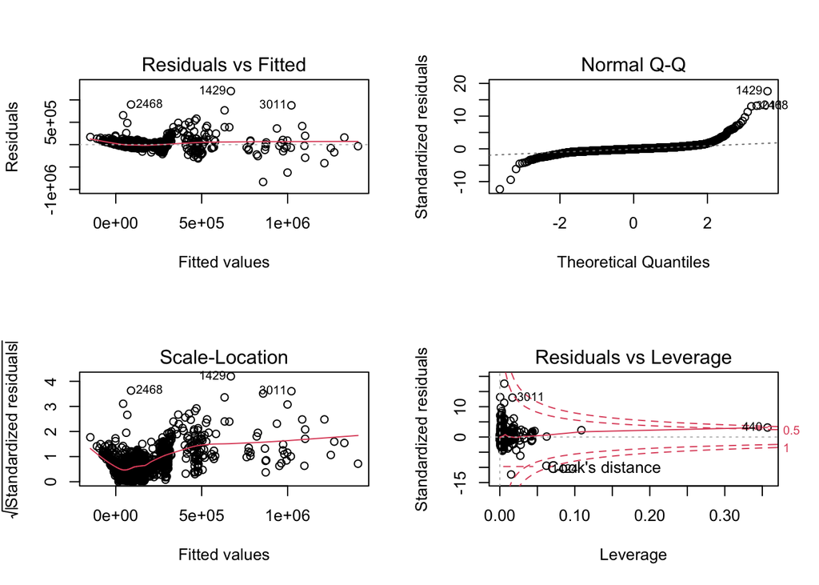

```r
par(mfrow=c(2,2))
plot(forward_model)
```

# Model 2 - Backward Propogation

```r
backward <- stepAIC(full_model, direction = "backward")
```

```
## Start:  AIC=78562.88
## price ~ (model_name + model_year + kms_driven + owner + location +
##     mileage + power) - model_name
##
##               Df  Sum of Sq        RSS   AIC
## - location   367 1.8229e+12 1.6279e+13 78246
## - mileage      1 5.5987e+09 1.4462e+13 78562
## <none>                      1.4457e+13 78563
## - kms_driven   1 1.8636e+10 1.4475e+13 78565
## - owner        3 3.4318e+11 1.4800e+13 78639
## - model_year   1 6.0775e+11 1.5064e+13 78706
## - power        1 3.3998e+13 4.8455e+13 82812
##
## Step:  AIC=78246.3
## price ~ model_year + kms_driven + owner + mileage + power
##
##              Df  Sum of Sq        RSS   AIC
## - mileage     1 2.9812e+09 1.6282e+13 78245
## <none>                     1.6279e+13 78246
## - kms_driven  1 3.2493e+10 1.6312e+13 78251
## - owner       3 2.9998e+11 1.6579e+13 78304
## - model_year  1 7.8054e+11 1.7060e+13 78409
## - power       1 3.5973e+13 5.2252e+13 82343
##
## Step:  AIC=78244.94
## price ~ model_year + kms_driven + owner + power
##
##              Df  Sum of Sq        RSS   AIC
## <none>                     1.6282e+13 78245
## - kms_driven  1 3.1377e+10 1.6314e+13 78250
## - owner       3 3.0078e+11 1.6583e+13 78303
## - model_year  1 7.7794e+11 1.7060e+13 78407
## - power       1 4.9296e+13 6.5579e+13 83140
```

```r
summary(backward)
```

```
##
## Call:
## lm(formula = price ~ model_year + kms_driven + owner + power,
##     data = bikeTraining[, 1:8])
##
## Residuals:
##     Min      1Q  Median      3Q     Max
## -834300  -25487   -2385   18956 1196381
##
## Coefficients:
##                             Estimate Std. Error t value Pr(>|t|)
## (Intercept)               -8.924e+06  6.865e+05 -12.998  < 2e-16 ***
## model_year                 4.409e+03  3.406e+02  12.946  < 2e-16 ***
## kms_driven                -1.115e-01  4.289e-02  -2.600  0.00936 **
## ownerfourth owner or more -9.818e+04  1.413e+04  -6.948 4.39e-12 ***
## ownersecond owner         -1.500e+04  3.754e+03  -3.997 6.55e-05 ***
## ownerthird owner          -1.716e+04  9.190e+03  -1.867  0.06203 .
## power                      7.257e+03  7.042e+01 103.057  < 2e-16 ***
## ---
## Signif. codes:  0 '***' 0.001 '**' 0.01 '*' 0.05 '.' 0.1 ' ' 1
##
## Residual standard error: 68130 on 3508 degrees of freedom
## Multiple R-squared:  0.7706, Adjusted R-squared:  0.7702
## F-statistic:  1964 on 6 and 3508 DF,  p-value: < 2.2e-16
```

> We see that the accuracy of the backward model is similar to that of the forward model.

### Calculation of the MAE and MSE for the backward model

```r
backward_pred <-predict(object = backward, newdata = bikeTesting[,1:8])
MAE(y_pred = backward_pred, y_true = bikeTesting$price)
```

```
## [1] 36904.04
```

```r
MSE(y_pred = backward_pred, y_true = bikeTesting$price)
```

```
## [1] 4586714815
```

### Plotting the Backward Propogation model

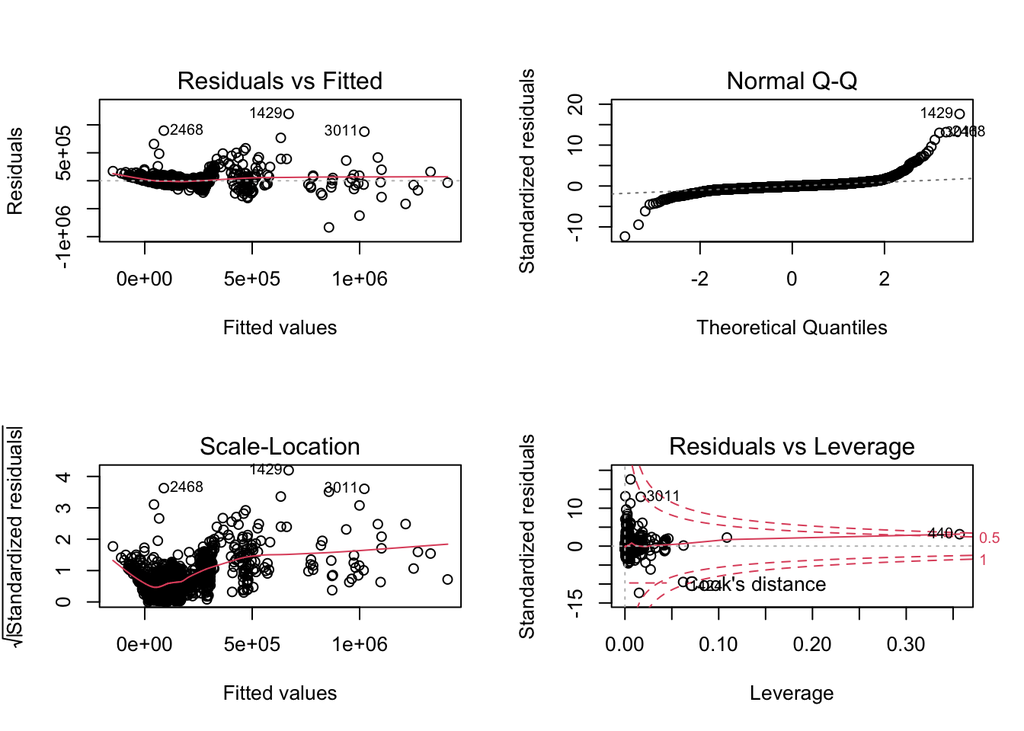

```r
par(mfrow = c(2,2))
plot(backward)
```

> We can see that both the models have the same accuracy and same mean square error and Mean absolute error. The accuracy for both the models is 77.02%.